# [EM6043] Data Management

Walter Quattrociocchi  
Fall 2018

**Text Mining in R**

## Example: Disney Pixar Facebook Page

[figure not shown]

### Load Libraries

```r
library(tm)
library(SnowballC)
```

### Load Data

```r
load("posts_disneypixar.RData")
str(posts)
```

```
'data.frame':   581 obs. of  12 variables:
 $ from_id       : num  3.52e+10 3.52e+10 3.52e+10 3.52e+10 3.52e+10 ...
 $ from_name     : chr  "Disney Pixar" "Disney Pixar" "Disney Pixar" "Disney Pixar" ...
 $ message       : chr  "Ring in the resolutions." "New year, new friends." "A sight to sea!" "Look back to look ahead." ...
 $ created_time  : chr  "2016-12-31T22:30:29+0000" "2016-12-31T18:00:01+0000" "2016-12-30T20:30:38+0000" "2016-12-30T01:00:03+0000" ...
 $ type          : chr  "video" "photo" "video" "photo" ...
 $ link          : chr  "https://www.facebook.com/DisneyPixar/videos/10154976061679078/" "https://www.facebook.com/DisneyPixar/photos/a.127437064077.102676.35245929077/10154975271164078/?type=3" "https://www.facebook.com/DisneyPixar/videos/10154972466094078/" "https://www.facebook.com/DisneyPixar/ph…
 $ post_id       : chr  "35245929077_10154976061679078" "35245929077_10154975271164078" "35245929077_10154972466094078" "35245929077_10154970190449078" ...
 $ story         : chr  "" "" "" "" ...
 $ likes_count   : int  3211 1416 714 2424 1859 6104 3236 1834 2301 1542 ...
 $ comments_count: int  103 13 3 19 27 390 67 37 37 8 ...
 $ shares_count  : int  763 39 14 131 240 1037 206 134 147 88 ...
 $ page_id       : chr  "35245929077" "35245929077" "35245929077" "35245929077" ...
```

### Load Data

```r
texts = posts$message
texts <- iconv(texts, 'UTF-8', 'ASCII') # encoding for emojis
```

### Create a Corpus

- We need to create a collection of documents (**Corpus**) in the R environment
- The `tm` package provides the `Corpus()` function to do this:

```r
corpus <- Corpus(VectorSource(texts))
```

Type in `corpus` to see some information about the newly created corpus:

```r
corpus
```

```
<<SimpleCorpus>>
Metadata:  corpus specific: 1, document level (indexed): 0
Content:  documents: 581
```

### Inspecting Content

The `summary()` function gives more details, including a complete listing of files, but it isn't particularly enlightening..

```r
head(summary(corpus))
```

```
  Length Class             Mode
1 2      PlainTextDocument list
2 2      PlainTextDocument list
3 2      PlainTextDocument list
4 2      PlainTextDocument list
5 2      PlainTextDocument list
6 2      PlainTextDocument list
```

### Inspecting Content

.. instead, we'll examine a particular document in the corpus:

```r
inspect(corpus[560])
```

```
<<SimpleCorpus>>
Metadata:  corpus specific: 1, document level (indexed): 0
Content:  documents: 1

[1] Come on, group hug! Inside Out is an Academy Award nominee for both Best Animated Feature Film and Original Screenplay, and Sanjay's Super Team is up for Best Animated Short.
```

```r
writeLines(as.character(corpus[[560]]))
```

```
Come on, group hug! Inside Out is an Academy Award nominee for both Best Animated Feature Film and Original Screenplay, and Sanjay's Super Team is up for Best Animated Short.
```

### Preprocessing your Data

- Data cleansing is tedious, but it is perhaps the most important step in text analysis
- The `tm` package offers a number of transformations for cleaning data
- To see the available transformations:

```r
getTransformations()
```

```
[1] "removeNumbers"     "removePunctuation" "removeWords"
[4] "stemDocument"      "stripWhitespace"
```

### Preprocessing

- We can also create a custom transformation
- The `tm` package provides the ability to do this via the `content_transformer` function
- This function takes as input a function which specifies what transformation needs to be done
- In the following case, the input function would be one that replaces all instances of a character by spaces:

```r
toSpace <- content_transformer(function(x, pattern) {return (gsub(pattern, " ", x))})
```

Now we can use this content transformer to eliminate colons and hypens:

```r
corpus <- tm_map(corpus, toSpace, "-")
corpus <- tm_map(corpus, toSpace, ":")
```

### Preprocessing

```r
# Convert the text to lower case
corpus <- tm_map(corpus, content_transformer(tolower))
writeLines(as.character(corpus[[560]]))
```

```
come on, group hug! inside out is an academy award nominee for both best animated feature film and original screenplay, and sanjay's super team is up for best animated short.
```

```r
# Remove numbers
corpus <- tm_map(corpus, removeNumbers)
writeLines(as.character(corpus[[560]]))
```

```
come on, group hug! inside out is an academy award nominee for both best animated feature film and original screenplay, and sanjay's super team is up for best animated short.
```

### Preprocessing

```r
# Remove English common stopwords
corpus <- tm_map(corpus, removeWords, stopwords("english"))
writeLines(as.character(corpus[[560]]))
```

```
come , group hug! inside    academy award nominee   best animated feature film  original screenplay,  sanjay's super team    best animated short.
```

```r
# Remove punctuations
corpus <- tm_map(corpus, removePunctuation)
writeLines(as.character(corpus[[560]]))
```

```
come  group hug inside    academy award nominee   best animated feature film  original screenplay  sanjays super team    best animated short
```

```r
# Eliminate extra white spaces
corpus <- tm_map(corpus, stripWhitespace)
```

### Stemming

- Typically a large corpus will contain many words that have a common root - for example: offer, offered and offering
- Stemming is the process of reducing inflected (or sometimes derived) words to their word stem, base or root form
- For example, changing “car”, “cars”, “car's”, “cars” to “car”
- Simple stemming algorithms (such as the one in `tm`) are relatively crude: they work by chopping off the ends of words

### The Document Term Matrix

- Now we need to create the **document term matrix** (DTM), a matrix that lists all occurrences of words in the corpus, by document
- In the DTM, documents are represented by rows and terms by columns
- If a word occurs in a particular document, then the matrix entry for the corresponding row and column is 1, else 0
- Multiple occurrences within a document are recorded (e.g., if a word occurs twice in a document, it is recorded as “2”“ in the relevant matrix entry)

### The Document Term Matrix: example

Doc1 = bananas are yellow  
Doc2 = bananas are good

The DTM for this corpus would look like:

[figure not shown]

Notice that:

- DTMs can be **huge**! The dimension of the matrix would be (number of documents)x(number of words in the corpus)
- The large majority of words will appear only in a few documents; as a result, a DTM is invariably **sparse** (i.e., a large number of its entries are 0)

### Creating a Document Term Matrix

Creating a DTM in R is as simple as:

```r
dtm = DocumentTermMatrix(corpus)
```

This creates a term document matrix from the corpus and stores the result in `dtm`.  
To get summary information on the matrix just type:

```r
dtm
```

```
<<DocumentTermMatrix (documents: 581, terms: 1351)>>
Non-/sparse entries: 2962/781969
Sparsity           : 100%
Maximal term length: 25
Weighting          : term frequency (tf)
```

### Word Frequency

To get the frequency of occurrence of each word in the corpus, we simply sum over all rows to give column sums:

```r
freq <- colSums(as.matrix(dtm))
freq[46:49]
```

```
    stuff adventure   cookies    hungry
        3        12         1         1
```

- First, we have converted the DTM into a mathematical matrix using the `as.matrix()` function
- Then, we have summed over all rows to give us the totals for each column (term)
- The result is stored in the (column matrix) variable `freq`

### Word Frequency

Check that the dimension of freq equals the number of terms:

```r
length(freq) == dim(dtm)[2]
```

```
[1] TRUE
```

And indeed:

```r
length(freq)
```

```
[1] 1351
```

```r
dim(dtm)[2]
```

```
[1] 1351
```

### Word Frequency

```r
# Create sort order (descending)
ord <- order(freq, decreasing = TRUE)
```

Then list the **most** and **least** frequently occurring terms:

```r
# Inspect most frequently occurring terms
freq[head(ord)]
```

```
   dory finding  disney     new    http     day
     76      75      35      34      34      27
```

```r
# Inspect least frequently occurring terms
freq[tail(ord)]
```

```
   peek     pow  whoosh  beauty   chill sequins
      1       1       1       1       1       1
```

### Word Frequency

- Let's take get a list of terms that occur at least a 10 times in the entire corpus
- This is easily done using the `findFreqTerms()` function as follows:

```r
findFreqTerms(dtm, lowfreq = 10)
```

```
 [1] "friends"   "new"       "look"      "get"       "just"
 [6] "like"      "time"      "adventure" "happy"     "little"
[11] "inside"    "day"       "can"       "world"     "disney"
[16] "family"    "make"      "art"       "dory"      "finding"
[21] "cars"      "disnbfcph" "today"     "now"       "http"
[26] "anywhere"  "blu"       "digital"   "movies"    "ray"
[31] "big"       "fin"       "side"      "short"     "one"
[36] "swims"     "theatres"  "take"      "whale"     "good"
[41] "come"      "let"       "see"       "june"
```

### Let's plot!

First, we may create a data frame like this:

```r
wf = data.frame(word = names(freq), # names() allows to get or set the names of an object
                freq = freq)
head(wf)
```

```
                   word freq
resolutions resolutions    1
ring               ring    2
friends         friends   17
new                 new   34
year               year    3
sea                 sea    9
```

### Let's plot!

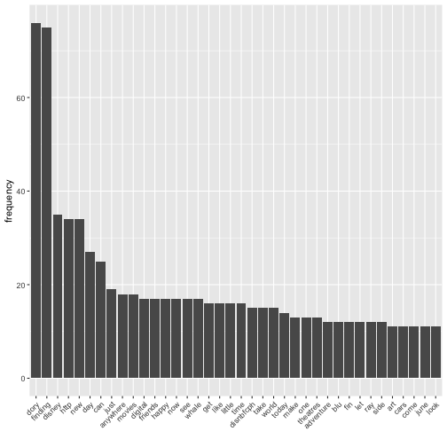

```r
library(ggplot2)
ggplot(subset(wf, freq>10), aes(x = reorder(word, -freq), y = freq)) +
  geom_bar(stat = "identity") +
  labs(x = "", y = "frequency") +
  theme(axis.text.x=element_text(angle=45, hjust=1))
```

### Wordcloud

[figure not shown]

```r
library(wordcloud)
wordcloud(wf$word, wf$freq,
          min.freq = 10,
          rot.per = 0.15,
          colors = brewer.pal(8, "Dark2")
)
```

### Wordcloud

[figure not shown]

```r
library(wordcloud)
wordcloud(wf$word, wf$freq,
          scale=c(5,0.5), min.freq = 5,
          random.order = F,
          rot.per = 0.15,
          colors = brewer.pal(8, "Spectral")
)
```

### More about Colors

- [Colors in R](http://www.stat.columbia.edu/%7Etzheng/files/Rcolor.pdf)
- [ColorBrewer Palettes](http://www.cse.unsw.edu.au/%7Emike/myrlibrary.old/RColorBrewer/html/ColorBrewer.html)

### Sentiment Analysis

```r
library('syuzhet')
```

- Package `syuzhet` uses [NRC Emotion lexicon](http://saifmohammad.com/WebPages/NRC-Emotion-Lexicon.htm)
- The NRC emotion lexicon is a list of words and their associations with eight emotions (anger, fear, anticipation, trust, surprise, sadness, joy, and disgust) and two sentiments (negative and positive)

### Sentiment Analysis

```r
sentiment = get_nrc_sentiment(texts)
td = data.frame(t(sentiment))
td[,1:5]
```

```
             X1 X2 X3 X4 X5
anger         0  0  0  0  0
anticipation  0  0  0  0  0
disgust       0  0  0  0  0
fear          0  0  0  0  1
joy           0  0  0  0  0
sadness       0  0  0  0  0
surprise      0  0  0  0  0
trust         0  0  0  0  0
negative      0  0  0  0  0
positive      0  0  1  1  1
```

### Transformation and Cleaning

```r
# Compute column sums across rows for each level of a grouping variable
td = data.frame(rowSums(td[-1]))
td
```

```
             rowSums.td..1..
anger                     59
anticipation             190
disgust                   35
fear                      99
joy                      172
sadness                   73
surprise                  84
trust                    130
negative                 133
positive                 284
```

### Transformation and Cleaning

```r
names(td)[1] <- "count"
td
```

```
             count
anger           59
anticipation   190
disgust         35
fear            99
joy            172
sadness         73
surprise        84
trust          130
negative       133
positive       284
```

### Transformation and Cleaning

```r
tdw <- cbind("sentiment" = rownames(td), td)
tdw
```

```
                sentiment count
anger               anger    59
anticipation anticipation   190
disgust           disgust    35
fear                 fear    99
joy                   joy   172
sadness           sadness    73
surprise         surprise    84
trust               trust   130
negative         negative   133
positive         positive   284
```

### Transformation and Cleaning

```r
rownames(tdw) <- NULL
tdw
```

```
      sentiment count
1         anger    59
2  anticipation   190
3       disgust    35
4          fear    99
5           joy   172
6       sadness    73
7      surprise    84
8         trust   130
9      negative   133
10     positive   284
```

### Sentiment Analysis

```r
td_em  = tdw[1:8, ] # emotions
td_pol = tdw[9:10, ] # polarity
```

### Plot Emotions

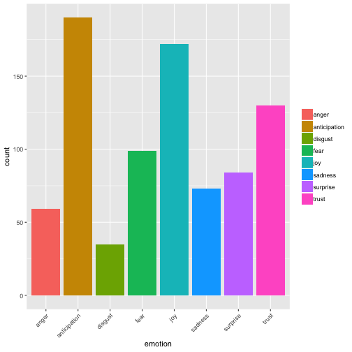

```r
require("ggplot2")
ggplot(td_em, aes(x = sentiment, y = count, fill = sentiment)) +
  geom_bar(stat = "identity") +
  labs(x = "emotion") +
  theme(axis.text.x=element_text(angle=45, hjust=1), legend.title = element_blank())
```

### Plot Polarity

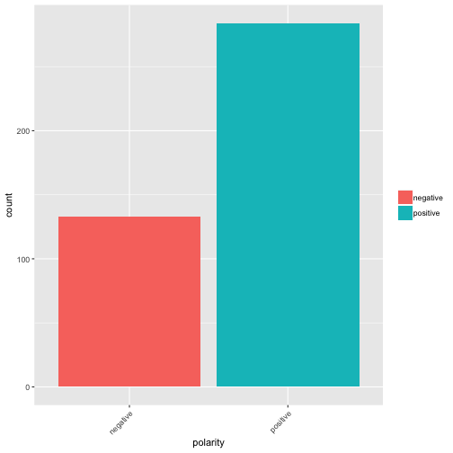

```r
require("ggplot2")
ggplot(td_pol, aes(x = sentiment, y = count, fill = sentiment)) +
  geom_bar(stat = "identity") +
  labs(x = "polarity") +
  theme(axis.text.x=element_text(angle=45, hjust=1), legend.title = element_blank())
```

### Still Interested in Text Analysis?

- Take a look at [Text Mining with R. A Tidy Approach](http://tidytextmining.com)

[figure not shown]

### Notes

Template of these slides is based on original material provided by Chris Chapman & Elea McDonnell Feit

These slides are based on the following tutorials:

- [Basic Text Mining in R](https://rstudio-pubs-static.s3.amazonaws.com/265713_cbef910aee7642dc8b62996e38d2825d.html)
- [A gentle introduction to text mining using R](https://eight2late.wordpress.com/2015/05/27/a-gentle-introduction-to-text-mining-using-r/)
- [Text mining in R: a tutorial](https://www.springboard.com/blog/text-mining-in-r/)

All code in the presentation is licensed under the Apache License, Version 2.0 (the “License”); you may not use this file except in compliance with the License. You may obtain a copy of the License at [http://www.apache.org/licenses/LICENSE-2.0\](http://www.apache.org/licenses/LICENSE-2.0%5C) Unless required by applicable law or agreed to in writing, software distributed under the License is distributed on an “AS IS” BASIS, WITHOUT WARRANTIES OR CONDITIONS OF ANY KIND, either express or implied. See the License for the specific language governing permissions and limitations under the License.